# Notebook 3 — Human-in-the-loop vs. 100 % autonomous vs. autopoietic control

**Project:** Real Autonomy in Autonomous Haulage · *Digital-twin experiments* **Site (anonymised):** *Mine A*, open-pit copper mine, *Region R* · **Operator (anonymised):** *Company X* **Runtime:** Google Colab (CPU is enough) · **Dependencies:** `numpy`, `pandas`, `matplotlib`, `scipy` (pre-installed in Colab)

> **Central question.** Who should close the control loop of an autonomous haulage system — a human dispatcher, a human approving an optimiser, a human supervising an autonomous optimiser, a fully autonomous central optimiser, or a **decentralised, self-organising (autopoietic)** system with no central node — and how does each behave in a normal shift and under stress?

**Five governance modes** (same trucks, same mine, same model parameters and seed indices; the stochastic trajectories can diverge after policies make different decisions)

| # | Mode | Dispatch decision | Exceptions (A-stops) | Depends on central FMS? |
| --- | --- | --- | --- | --- |
| 1 | Human-only | Human on the radio, 6-min-old picture, noisy, absent at breaks | Human, 6 min | No (radio) |
| 2 | Human-**in**-the-loop | Optimiser proposes, human **approves each assignment** (~1.5 min, 8 % veto, timeout at breaks) | Human, 6 min | Yes |
| 3 | Human-**on**-the-loop | Optimiser executes automatically, human supervises | Human, 6 min (+ breaks) | Yes |
| 4 | 100 % autonomous, central | Optimiser, no human | Field crew, 18 min | Yes |
| 5 | **Autopoietic** | Stigmergic environmental flow/cost marks and local realised outcomes; softmax choice | Peer-assisted, 12 min; no control-room touch counted | **No** |

**Four scenarios:** *Normal shift* · *FMS/network outage* 120 min · *Shovel SH-2 failure* 120 min · *Compound* (both at once). **How to use this notebook.** Run the cells top to bottom (*Runtime → Run all*). Every experiment uses fixed random seeds, so you should reproduce the numbers quoted in the interpretation cells within the printed confidence intervals. Result cells are followed by an **input and output interpretation** section that states what the table or figure supports and what it does not.

**Anonymisation.** Company, mine, region and equipment identifiers were replaced (*Company X*, *Mine A*, *Region R*, shovels `SH-1…SH-5`, trucks `AHT-01…AHT-23`). The Time Usage Model codes, the ten cycle phases and the KPI definitions are kept exactly as in the source documents because they are the shared language of the analysis.

## 0. Contents

1. Governance-configuration inputs and assumptions
2. Shared simulator and mode code
3. Five configurations × four scenarios
4. Operator workload, holding time and failure trace
5. Sensitivity to approval, A-stop clearance and fallback design
6. Limitations
7. References
8. Disclaimer

## 1. Governance-configuration inputs and assumptions

**Human involvement.** *In-the-loop* places approval inside every dispatch cycle; *on-the-loop* lets the optimiser execute while the human supervises exceptions [PSW]. Automation literature warns that exception-only roles can reduce situation awareness and slow re-entry [BAIN][ENDS].

**Stigmergic configuration.** The decentralised policy uses two shared environmental marks per shovel: a short-lived flow footprint and an evaporating realised-cost mark [GRASSE][BDT][DORIGO]. It does **not** read the global physical-queue vector, the central dispatch log or the central FMS snapshot. A truck that reaches an unavailable shovel sets a repellent mark when it locally triggers diversion; successful loads update the cost mark from that truck's realised dispatch-to-load time. This is a narrow operational analogy to self-organisation, not a complete biological model of autopoiesis [MV].

**Human availability.** The model includes two 30-min breaks (minutes 240–270 and 480–510). Human-only follows its home plan during those intervals; HITL auto-accepts the optimiser's first choice after a maximum 5-min timeout, without recording a human touch or applying a veto; HOTL A-stops wait for the operator's return.

**Central outage.** HITL, HOTL and autonomous-central hold trucks during an FMS outage, then fall back to the home-allocation plan after 10 min. Trucks queued at a failed shovel cannot use central redirection while the FMS is unavailable. Human-only uses radio and the stigmergic policy uses its environmental marks, so neither depends on that central node.

**Causal boundary.** These are five **bundled governance configurations**. They differ simultaneously in information lag, observation noise, approval delay, veto behavior, redirection delay, A-stop response and fallback logic. Their pairwise differences therefore describe whole configurations; they do not isolate a pure causal “human effect.” Section 5 varies selected inputs one at a time.

## 2. Simulator and governance-mode code

```python
import numpy as np, pandas as pd, math
from scipy.stats import t as student_t
try:
    from IPython.display import display
except ImportError:          # plain-python fallback
    display = print
import matplotlib
import matplotlib.pyplot as plt
plt.rcParams.update({"figure.dpi": 110, "axes.grid": True, "grid.alpha": .25,
                     "axes.spines.top": False, "axes.spines.right": False, "font.size": 9})
from collections import deque
from dataclasses import dataclass, replace

# ---------------------------------------------------------------- state ids
TE, QS, SS, WL, LD, TF, QK, SK, WD, DP, DN, RF, HD, E70, E110, E60, PD = range(17)
PHASES = ["Travelling Empty", "Queuing At Source", "Spotting At Source", "Wait for load", "Loading",
          "Travelling Full", "Queuing at sink", "Spotting at sink", "Wait for Dump", "Dumping"]
SLOT_NAME = PHASES + ["Breakdown (5000)", "Refuel (2020)", "Hold: wait dispatch/approval (4060/4150)",
                      "Obstacle / interaction stop (4070)", "Emergency A-stop (4110)", "Autonomy HW event (5060)", "Process delays (2xxx/4xxx)"]
SLOT_CODE = [1010, 7010, 1010, 7000, 1010, 1010, 7020, 1010, 7000, 1010, 5000, 2020, 4060, 4070, 4110, 5060, 4000]
QUEUE_SLOTS = (QS, QK)              # non value-adding queues (TUM 7010 / 7020)
DOWN_SLOTS = (DN, E60)              # equipment downtime (TUM 5xxx)
CYCLE_SLOTS = list(range(10))

# Reference values read from the (anonymised) operations dashboard, 8-16 Mar window
REF = {"Travelling Empty": 9.90, "Queuing At Source": 6.06, "Spotting At Source": 1.03, "Wait for load": 1.24,
       "Loading": 2.42, "Travelling Full": 9.14, "Queuing at sink": 1.56, "Spotting at sink": 0.70,
       "Wait for Dump": 0.37, "Dumping": 1.09}
REF_KPI = {"cycle_time": 33.51, "availability": 84.39, "utilization": 66.20, "tph_productive": 787.01,
           "hang_time": 2.24, "load_factor_t": 338.0}


@dataclass
class P:
    n_trucks: int = 23
    T: float = 720.0            # one 12 h shift, minutes
    warm: float = 60.0          # warm-up discarded from KPIs
    dt: float = 0.25
    payload: float = 338.0
    # per-shovel geometry (minutes) -> 5 active shovels (a 6th is out of service in the reference data)
    te: tuple = (7.0, 9.1, 10.2, 12.8, 14.4)
    tf: tuple = (6.6, 8.6, 9.6, 11.8, 13.4)
    load: tuple = (2.2, 2.4, 2.4, 2.6, 2.7)
    spot_src: float = 1.03
    wait_load: float = 1.24
    spot_sink: float = 0.70
    wait_dump: float = 0.37
    dump: float = 1.09
    sink_bays: int = 2
    sink_block_mtbf: float = 60.0   # crusher / dump-pocket blockages (min between events)
    sink_block_min: float = 7.0
    static_alloc: tuple = (9, 5, 4, 3, 2)
    cv: float = 0.25
    mtbf_h: float = 10.0
    mttr_h: float = 1.85
    shovel_mtbf_h: float = 30.0
    shovel_mttr_h: float = 1.5
    refuel_min: float = 12.0
    proc_p: float = 0.40        # prob. of a process delay (shift hand-over, lock-outs, weather...) at a decision point
    proc_mean: float = 8.0
    # interaction with heterogeneous traffic (manual / light vehicles / other autonomy stacks)
    lam_int: float = 0.020      # events per travelling minute
    comms_cov: float = 0.5      # 0 = no heterogeneous comms, 1 = full interoperability
    d_soft: float = 0.4
    d_hard: float = 3.5
    p_astop: float = 0.06       # probability that an uncoordinated hard stop escalates to an A-stop
    d_astop: float = 14.0
    lam_hw: float = 0.0015      # autonomy hardware events per travelling minute
    d_hw: float = 6.0
    handshake_gain: float = 0.0  # fraction of spot/wait-for-load time removed by full truck-shovel comms
    shovel_outages: tuple = ()  # ((shovel, start_min, end_min), ...)
    system_outages: tuple = ()  # ((start_min, end_min), ...) central FMS / network outage
    fallback_min: float = 10.0  # after this long in an outage, centralised policies fall back to the static plan
    seed: int = 0


HALF_DT = 0.125   # a timer that is decremented every dt overshoots by dt/2 on average -> compensate


def _ln(rng, mean, cv):
    s2 = math.log(1 + cv * cv)
    return max(0.02, rng.lognormal(math.log(mean) - s2 / 2, math.sqrt(s2)) - HALF_DT)


class Sim:
    def __init__(self, p: P, policy):
        self.p, self.policy = p, policy
        seed_seq = np.random.SeedSequence(p.seed)
        env_seed, policy_seed = seed_seq.spawn(2)
        self.rng = np.random.default_rng(env_seed)
        self.policy_rng = np.random.default_rng(policy_seed)
        N, M = p.n_trucks, len(p.te)
        self.N, self.M = N, M
        self.state = [TE] * N; self.left = [0.0] * N; self.tgt = [0] * N
        self.evt_left = [0.0] * N; self.evt_slot = [E70] * N
        self.hold_left = [0.0] * N; self.pending_tgt = [0] * N
        self.disp_t = [0.0] * N; self.disp_phi = [None] * N
        self.cycle_start = [0.0] * N
        self.fail_t = [self.rng.exponential(p.mtbf_h * 60) for _ in range(N)]
        self.refuel_t = [self.rng.uniform(200, 560) for _ in range(N)]
        self.acct = np.zeros((N, 17))
        self.shq = [[] for _ in range(M)]; self.occ = [-1] * M
        self.committed = [0] * M
        self.down = [False] * M
        self.sh_next_fail = [self.rng.exponential(p.shovel_mtbf_h * 60) for _ in range(M)]
        self.sh_up_at = [0.0] * M
        self.idle = np.zeros(M); self.loads = np.zeros(M); self.qtime = np.zeros(M)
        self.skq = []; self.sink_occ = 0
        self.sink_next_block = self.rng.exponential(p.sink_block_mtbf); self.sink_blocked_until = 0.0
        self.dump_times = []
        self.trips = 0; self.cycles = []; self.n_evt = {E70: 0, E110: 0, E60: 0}
        self.n_touch = 0; self.hist = []; self.dlog = deque()
        self.t = 0.0; self.k = 0
        self.home = []
        for a, n in enumerate(p.static_alloc):
            self.home += [a] * n
        self.home = (self.home + [0] * N)[:N]
        self.qdown_since = [None] * N
        self.tons_log = []
        for i in range(N):
            a = self._pick(i)
            self._depart(i, a, frac=self.rng.uniform(0.2, 1.0))
```

```python
    # ------------------------------------------------------------ observation API used by policies
    def obs(self, lag):
        if lag <= 0 or not self.hist:
            return list(self.committed), list(self.down)
        idx = max(0, len(self.hist) - 1 - int(round(lag / self.p.dt)))
        return self.hist[idx]

    def recent(self, lag):
        c = [0] * self.M
        for (t, a) in self.dlog:
            if t > self.t - lag:
                c[a] += 1
        return c

    def in_outage(self):
        for (a, b) in self.p.system_outages:
            if a <= self.t < b:
                return a
        return None

    def phys_queue(self):
        return [len(q) + (1 if self.occ[a] >= 0 else 0) for a, q in enumerate(self.shq)]

    # ------------------------------------------------------------ helpers
    def _pick(self, i, redirect=False):
        a = self.policy.choose(self, i, redirect)
        self.disp_phi[i] = getattr(self.policy, "last_phi", None)
        return a

    def _depart(self, i, a, frac=1.0):
        p = self.p
        self.tgt[i] = a; self.committed[a] += 1; self.disp_t[i] = self.t
        self.dlog.append((self.t, a))
        while self.dlog and self.dlog[0][0] < self.t - 30:
            self.dlog.popleft()
        self.state[i] = TE
        self.left[i] = _ln(self.rng, p.te[a], p.cv) * frac

    def _next(self, i):
        """decision point after dumping / repair / refuel"""
        p = self.p
        if self.t >= self.fail_t[i]:
            self.state[i] = DN
            self.left[i] = _ln(self.rng, p.mttr_h * 60, 0.5)
            self.fail_t[i] = self.t + self.left[i] + self.rng.exponential(p.mtbf_h * 60)
            return
        if self.t >= self.refuel_t[i]:
            self.state[i] = RF; self.left[i] = _ln(self.rng, p.refuel_min, 0.2)
            self.refuel_t[i] = 1e9
            return
        if self.rng.random() < p.proc_p:
            self.state[i] = PD; self.left[i] = _ln(self.rng, p.proc_mean, 0.6)
            return
        self._dispatch(i)

    def _dispatch(self, i):
        p = self.p
        pol = self.policy
        if getattr(pol, "central", False):
            o = self.in_outage()
            if o is not None:
                if self.t - o < p.fallback_min:
                    self.state[i] = HD; self.left[i] = p.dt
                    self.pending_tgt[i] = -1
                    return
                a = self.home[i]
                self._depart(i, a); self.disp_phi[i] = None
                return
        a = self._pick(i)
        d = getattr(pol, "delay", lambda s, i: 0.0)(self, i)
        if d > 0:
            self.pending_tgt[i] = a; self.state[i] = HD; self.left[i] = d
            self.committed[a] += 1  # commitment visible immediately
            return
        self._depart(i, a)

    def _spawn_event(self, i):
        p, r = self.p, self.rng
        cov = p.comms_cov
        if r.random() < p.lam_int * p.dt:
            self.evt_slot[i] = E70
            if r.random() < cov:
                self.evt_left[i] = r.exponential(p.d_soft)
            else:
                self.evt_left[i] = r.exponential(p.d_hard)
                if r.random() < p.p_astop:
                    self.evt_slot[i] = E110
                    self.evt_left[i] = _ln(r, self.policy.astop_delay(self) if hasattr(self.policy, "astop_delay") else p.d_astop, 0.4)
                    self.n_evt[E110] += 1
                    self.n_touch += getattr(self.policy, "astop_touch", 1)
            self.n_evt[E70] += 1
        elif r.random() < p.lam_hw * p.dt:
            self.evt_slot[i] = E60; self.evt_left[i] = _ln(r, p.d_hw, 0.4); self.n_evt[E60] += 1

    # ------------------------------------------------------------ main loop
    def _truck(self, i):
        p, dt = self.p, self.p.dt
        if self.evt_left[i] > 0:
            self.acct[i][self.evt_slot[i]] += dt; self.evt_left[i] -= dt
            return
        st = self.state[i]
        self.acct[i][st] += dt
        if st in (TE, TF):
            self._spawn_event(i)
        if st == QS:
            a = self.tgt[i]
            if self.down[a]:
                if self.qdown_since[i] is None:
                    self.qdown_since[i] = self.t
                if self.t - self.qdown_since[i] >= self.policy.redirect_delay and not (
                        getattr(self.policy, "central", False) and self.in_outage() is not None):
                    self.shq[a].remove(i); self.committed[a] -= 1; self.qdown_since[i] = None
                    b = self._pick(i, redirect=True)
                    self._depart(i, b, frac=0.6)
            else:
                self.qdown_since[i] = None
            return
        if st == QK:
            return
        if st == HD:
            self.left[i] -= dt
            if self.pending_tgt[i] == -1:      # waiting out a system outage
                if self.in_outage() is None or self.t - self.in_outage() >= p.fallback_min:
                    self._dispatch(i)
                return
            if self.left[i] <= 0:
                a = self.pending_tgt[i]; self.committed[a] -= 1
                self._depart(i, a)
            return
        self.left[i] -= dt
        if self.left[i] > 0:
            return
        a = self.tgt[i]
        if st == TE:
            self.state[i] = QS; self.shq[a].append(i)
        elif st == SS:
            self.state[i] = WL; self.left[i] = _ln(self.rng, p.wait_load * (1 - 0.7 * p.handshake_gain), p.cv * 2)
        elif st == WL:
            self.state[i] = LD; self.left[i] = _ln(self.rng, p.load[a], p.cv)
        elif st == LD:
            self.state[i] = TF; self.left[i] = _ln(self.rng, p.tf[a], p.cv)
            self.occ[a] = -1; self.committed[a] -= 1; self.loads[a] += 1
            if hasattr(self.policy, "on_loaded"):
                self.policy.on_loaded(self, i, a, self.t - self.disp_t[i])
        elif st == TF:
            self.state[i] = QK; self.skq.append(i)
        elif st == SK:
            self.state[i] = WD; self.left[i] = _ln(self.rng, p.wait_dump, p.cv * 2)
        elif st == WD:
            self.state[i] = DP; self.left[i] = _ln(self.rng, p.dump, p.cv)
        elif st == DP:
            self.sink_occ -= 1
            if self.t >= p.warm:
                self.trips += 1; self.cycles.append(self.t - self.cycle_start[i]); self.dump_times.append(self.t)
            self.cycle_start[i] = self.t
            self._next(i)
        elif st in (DN, RF):
            self._next(i)
        elif st == PD:
            self._dispatch(i)
```

```python
    def _shovels(self):
        p = self.p
        for a in range(self.M):
            # scripted + random outages (start only when shovel is free)
            forced = any(s == a and b <= self.t < c for (s, b, c) in p.shovel_outages)
            if self.down[a]:
                if not forced and self.t >= self.sh_up_at[a]:
                    self.down[a] = False
                    self.sh_next_fail[a] = self.t + self.rng.exponential(p.shovel_mtbf_h * 60)
            elif self.occ[a] == -1 and (forced or self.t >= self.sh_next_fail[a]):
                self.down[a] = True
                self.sh_up_at[a] = self.t + (0 if forced else _ln(self.rng, p.shovel_mttr_h * 60, 0.5))
            if not self.down[a] and self.occ[a] == -1 and self.shq[a]:
                i = self.shq[a].pop(0)
                self.occ[a] = i; self.state[i] = SS
                self.left[i] = _ln(self.rng, p.spot_src * (1 - 0.7 * p.handshake_gain), p.cv)
            if self.t >= p.warm:
                self.qtime[a] += p.dt * len(self.shq[a])
            if not self.down[a] and self.occ[a] == -1 and not self.shq[a] and self.t >= p.warm:
                self.idle[a] += p.dt

    def _sink(self):
        p = self.p
        if self.t >= self.sink_next_block:
            self.sink_blocked_until = self.t + _ln(self.rng, p.sink_block_min, 0.5)
            self.sink_next_block = self.sink_blocked_until + self.rng.exponential(p.sink_block_mtbf)
        if self.t < self.sink_blocked_until:
            return
        while self.sink_occ < p.sink_bays and self.skq:
            i = self.skq.pop(0); self.sink_occ += 1
            self.state[i] = SK; self.left[i] = _ln(self.rng, p.spot_sink, p.cv)

    def run(self):
        p = self.p
        for k in range(int(p.T / p.dt)):
            self.k = k; self.t = k * p.dt
            if abs(self.t - p.warm) < 1e-9:
                self.acct[:] = 0; self.idle[:] = 0; self.qtime[:] = 0; self.trips = 0; self.cycles = []; self.loads[:] = 0
                self.n_evt = {E70: 0, E110: 0, E60: 0}; self.n_touch = 0; self.dump_times = []
            for i in range(self.N):
                self._truck(i)
            self._shovels(); self._sink()
            self.hist.append((list(self.committed), list(self.down)))
            if len(self.hist) > 200:
                self.hist.pop(0)
        return self.metrics()

    def metrics(self):
        p = self.p
        tot = self.acct.sum()
        by = self.acct.sum(axis=0)
        down = sum(by[s] for s in DOWN_SLOTS)
        prod = sum(by[s] for s in CYCLE_SLOTS if s not in QUEUE_SLOTS)      # dashboard definition: cycle minus queues
        tum_prod = by[[TE, SS, LD, TF, SK, DP]].sum()                      # strict TUM 1010
        hrs = (p.T - p.warm) / 60
        tons = self.trips * p.payload
        trips = max(self.trips, 1)
        m = dict(trips=self.trips, tons=tons, tph_fleet=tons / hrs,
                 availability=100 * (1 - down / tot), utilization=100 * prod / (tot - down),
                 utilization_tum=100 * tum_prod / (tot - down),
                 tph_productive=tons / (prod / 60) if prod > 0 else 0.0,
                 cycle_time=float(by[CYCLE_SLOTS].sum() / trips),
                 cycle_wall=float(np.mean(self.cycles)) if self.cycles else float("nan"),
                 hang_time=float(self.idle.sum() / max(self.loads.sum(), 1)),
                 queue_src=by[QS] / trips, queue_sink=by[QK] / trips,
                 astops=self.n_evt[E110], stops=self.n_evt[E70], hw_events=self.n_evt[E60],
                 touches=self.n_touch, annual_Mt=tons / hrs * 8760 / 1e6,
                 loads=list(self.loads), idle=list(self.idle), qtime=list(self.qtime))
        for s in range(17):
            m["min_" + str(s)] = by[s] / trips           # minutes per trip in each slot
            m["share_" + str(s)] = 100 * by[s] / tot
        return m


# ================================================================ policies
class Static:
    name = "Static plan"; central = False; redirect_delay = 8.0
    def choose(self, s, i, redirect=False):
        return s.home[i] if not redirect else int(np.argmin([s.p.te[a] if not s.down[a] else 99 for a in range(s.M)]))


class Nearest:
    name = "Nearest shovel"; central = True; redirect_delay = 1.0
    def choose(self, s, i, redirect=False):
        return int(np.argmin([s.p.te[a] + (99 if s.down[a] else 0) for a in range(s.M)]))


class GreedyObs:
    """expected-time greedy on a (possibly stale) telemetry snapshot; svc = minutes of shovel time per truck"""
    central = True; redirect_delay = 1.0
    def __init__(self, lag=0.0, svc=4.5, noise=0.0, name=None):
        self.lag, self.svc, self.noise = lag, svc, noise
        self.name = name or f"Greedy (info lag {lag:g} min)"
    def choose(self, s, i, redirect=False):
        c, dn = s.obs(self.lag)
        est = []
        for a in range(s.M):
            e = max(s.p.te[a], c[a] * self.svc)
            if dn[a]:
                e += 60
            if self.noise:
                e *= s.policy_rng.lognormal(0, self.noise)
            est.append(e)
        return int(np.argmin(est))


# ================================================================ experiment helpers
def replicate(make_policy, n=20, seed0=0, keep_sims=False, **kw):
    """Run n independent replications (different random seeds) and return a DataFrame of KPIs."""
    rows, sims = [], []
    for k in range(n):
        sim = Sim(P(seed=seed0 + k, **kw), make_policy())
        m = sim.run(); m["seed"] = seed0 + k
        rows.append(m); sims.append(sim)
    df = pd.DataFrame(rows)
    return (df, sims) if keep_sims else df


def ci95(x):
    """Two-sided 95% half-width using Student's t for the finite replication count."""
    x = np.asarray(x, float)
    if len(x) < 2:
        return float("nan")
    return student_t.ppf(0.975, len(x) - 1) * x.std(ddof=1) / np.sqrt(len(x))


def tons_series(sim, bin_min=30):
    edges = np.arange(sim.p.warm, sim.p.T + 1e-9, bin_min)
    h, _ = np.histogram(sim.dump_times, bins=edges)
    return edges[:-1] + bin_min / 2, h * sim.p.payload / (bin_min / 60)     # t/h in each bin
```

```python
def summarize(df, cols=("tph_fleet", "cycle_time", "queue_src", "queue_sink", "availability", "utilization", "tph_productive")):
    return pd.DataFrame({c: [f"{df[c].mean():.1f} ± {ci95(df[c]):.1f}"] for c in cols})
```

```python
HUMAN_OFF = ((240, 270), (480, 510))     # meal breaks (min from shift start) - no human dispatcher / supervisor available

def human_off_remaining(t):
    for a, b in HUMAN_OFF:
        if a <= t < b: return b - t
    return 0.0

def _rank_greedy(s, lag, svc=4.5, noise=0.0):
    c, dn = s.obs(lag)
    est = np.array([max(s.p.te[a], c[a] * svc) + (60 if dn[a] else 0) for a in range(s.M)], float)
    if noise: est *= s.policy_rng.lognormal(0, noise, s.M)
    return est

class HumanOnly:
    """Human dispatcher on the radio: perceives a 6-min-old picture with noise; unavailable during meal breaks."""
    name = "1 Human-only"; central = False; redirect_delay = 8.0
    def choose(self, s, i, redirect=False):
        if human_off_remaining(s.t) > 0:
            if redirect:                           # local fail-safe diversion; no dispatcher touch
                return int(np.argmin([s.p.te[a] if not s.down[a] else 99 for a in range(s.M)]))
            return s.home[i]                       # nobody at the desk -> follow the static plan
        s.n_touch += 1
        return int(np.argmin(_rank_greedy(s, 6, noise=0.25)))
    def delay(self, s, i): return 0.5
    def astop_delay(self, s): return 6.0 + human_off_remaining(s.t)
    astop_touch = 1

class HITL:
    """Optimiser proposes, a human approves every assignment (latency, occasional veto, breaks)."""
    name = "2 Human-in-the-loop"; central = True; redirect_delay = 3.0
    def __init__(self, approve_lat=1.5, veto=0.08): self.lat, self.veto = approve_lat, veto
    def choose(self, s, i, redirect=False):
        est = _rank_greedy(s, 1); order = np.argsort(est)
        if human_off_remaining(s.t) > 0: return int(order[0])    # timeout path: no human veto or touch
        s.n_touch += 1
        if s.policy_rng.random() < self.veto: return int(order[1])
        return int(order[0])
    def delay(self, s, i):
        off = human_off_remaining(s.t)
        return min(off, 5.0) if off > 0 else _ln(s.policy_rng, self.lat, 0.5)   # timeout after 5 min -> auto-accept
    def astop_delay(self, s): return 6.0 + human_off_remaining(s.t)
    astop_touch = 1

class HOTL:
    """Human ON the loop: optimiser executes autonomously, humans supervise and clear exceptions."""
    name = "3 Human-on-the-loop"; central = True; redirect_delay = 1.5
    def choose(self, s, i, redirect=False): return int(np.argmin(_rank_greedy(s, 1)))
    def astop_delay(self, s): return 6.0 + human_off_remaining(s.t)
    astop_touch = 1

class AutoCentral:
    """100 % autonomous, centralised optimiser, no human supervision (field crew needed for A-stops)."""
    name = "4 Autonomous (central)"; central = True; redirect_delay = 1.0
    def __init__(self, astop_min=18.0): self.a = astop_min
    def choose(self, s, i, redirect=False): return int(np.argmin(_rank_greedy(s, 1)))
    def astop_delay(self, s): return self.a
    astop_touch = 0

class Autopoietic:

    """Decentralised stigmergic dispatcher using only persistent environmental marks and local outcomes."""

    name = "5 Autopoietic (stigmergic)"; central = False; redirect_delay = 2.0

    def __init__(self, rho=0.03, w=0.1, temp=1.0, svc=4.5, astop_min=12.0, M=5):

        self.rho, self.w, self.temp, self.svc, self.a = rho, w, temp, svc, astop_min

        self.cost_mark = np.zeros(M); self.flow_mark = np.zeros(M); self.t_last = 0.0; self.pred = {}

    def _evap(self, s):

        elapsed = max(0.0, s.t - self.t_last)

        self.cost_mark *= math.exp(-self.rho * elapsed)

        self.flow_mark *= math.exp(-0.12 * elapsed)

        self.t_last = s.t

    def choose(self, s, i, redirect=False):

        self._evap(s)

        if redirect:                              # the arriving truck locally detected a failed shovel

            failed = s.tgt[i]

            self.cost_mark[failed] = max(self.cost_mark[failed], 40.0)

        est = np.asarray(s.p.te) + self.svc * self.flow_mark + self.cost_mark

        z = -(est - est.min()) / self.temp; pr = np.exp(z); pr /= pr.sum()

        a = int(s.policy_rng.choice(s.M, p=pr))

        self.pred[i] = est[a]; self.flow_mark[a] += 1.0

        return a

    def on_loaded(self, s, i, a, cost):

        self._evap(s)

        if i in self.pred:

            self.cost_mark[a] = float(np.clip(self.cost_mark[a] + self.w * (cost - self.pred.pop(i)), 0.0, 40.0))

    def astop_delay(self, s): return self.a

    astop_touch = 0
```

## 3. Experiment — 5 modes × 4 scenarios (20 replications each)

```
== Normal shift
   3 Human-on-the-loop − 4 Autonomous (central):    +97 t/h (±219)
   5 Autopoietic (stigmergic) − 4 Autonomous (central):   +187 t/h (±218)
   5 Autopoietic (stigmergic) − 3 Human-on-the-loop:    +91 t/h (±207)
   3 Human-on-the-loop − 2 Human-in-the-loop:   +475 t/h (±200)
   2 Human-in-the-loop − 1 Human-only:   +240 t/h (±187)
== Compound (both)
   3 Human-on-the-loop − 4 Autonomous (central):    +57 t/h (±169)
   5 Autopoietic (stigmergic) − 4 Autonomous (central):   +707 t/h (±148)
   5 Autopoietic (stigmergic) − 3 Human-on-the-loop:   +650 t/h (±169)
   3 Human-on-the-loop − 2 Human-in-the-loop:   +369 t/h (±183)
   2 Human-in-the-loop − 1 Human-only:   -318 t/h (±161)
```

|  | Normal shift | FMS outage 120 min | Shovel SH-2 down 120 min | Compound (both) |
| --- | --- | --- | --- | --- |
| 1 Human-only | 10,916 ± 171 | 10,916 ± 171 | 10,854 ± 194 | 10,854 ± 194 |
| 2 Human-in-the-loop | 11,156 ± 166 | 11,113 ± 185 | 11,030 ± 146 | 10,536 ± 172 |
| 3 Human-on-the-loop | 11,630 ± 160 | 11,455 ± 183 | 11,434 ± 182 | 10,905 ± 191 |
| 4 Autonomous (central) | 11,533 ± 191 | 11,447 ± 212 | 11,492 ± 124 | 10,848 ± 201 |
| 5 Autopoietic (stigmergic) | 11,721 ± 196 | 11,721 ± 196 | 11,555 ± 153 | 11,555 ± 153 |

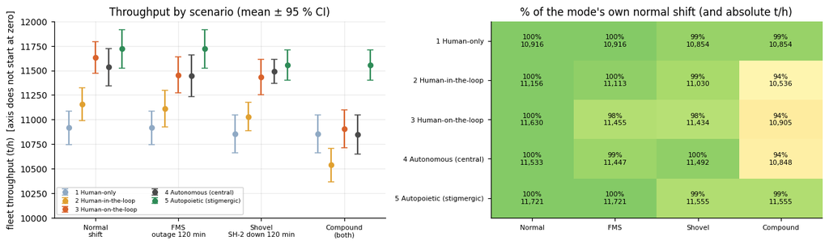

```python
MODES = [HumanOnly, HITL, HOTL, AutoCentral, Autopoietic]
SCEN = {"Normal shift": {},
        "FMS outage 120 min": dict(system_outages=((200, 320),)),
        "Shovel SH-2 down 120 min": dict(shovel_outages=((1, 200, 320),)),
        "Compound (both)": dict(system_outages=((200, 320),), shovel_outages=((1, 200, 320),))}
R, KEEP = {}, {}
for sn, kw in SCEN.items():
    for cls in MODES:
        df, sims = replicate(cls, n=20, keep_sims=True, **kw); R[(sn, cls.name)] = df; KEEP[(sn, cls.name)] = sims
names = [c.name for c in MODES]
tab = pd.DataFrame({sn: [f"{R[(sn, m)].tph_fleet.mean():,.0f} ± {ci95(R[(sn, m)].tph_fleet):.0f}" for m in names] for sn in SCEN}, index=names)
display(tab)

Z = np.array([[R[(sn, m)].tph_fleet.mean() for sn in SCEN] for m in names])
fig, axs = plt.subplots(1, 2, figsize=(12, 3.6))
w = 0.16; cols = ["#8fa9c4", "#e0a030", "#d9622b", "#4a4a4a", "#2e8b57"]
for j, m in enumerate(names):
    axs[0].errorbar(np.arange(4) + (j - 2) * w, Z[j], yerr=[ci95(R[(sn, m)].tph_fleet) for sn in SCEN], fmt="o", ms=5, color=cols[j], label=m, capsize=3)
axs[0].set_xticks(range(4)); axs[0].set_xticklabels([s.replace(" ", "\n", 1) for s in SCEN], fontsize=7); axs[0].set_ylim(10000, 12000)
axs[0].set_ylabel("fleet throughput (t/h)  [axis does not start at zero]"); axs[0].legend(fontsize=6, ncol=2); axs[0].set_title("Throughput by scenario (mean ± 95 % CI)")
axs[1].imshow(Z / Z[:, [0]] * 100, cmap="RdYlGn", vmin=85, vmax=105, aspect="auto"); axs[1].grid(False)
for i in range(5):
    for j in range(4): axs[1].text(j, i, f"{100*Z[i,j]/Z[i,0]:.0f}%\n{Z[i,j]:,.0f}", ha="center", va="center", fontsize=7)
axs[1].set_xticks(range(4)); axs[1].set_xticklabels([s.split()[0] for s in SCEN], fontsize=7); axs[1].set_yticks(range(5)); axs[1].set_yticklabels(names, fontsize=7)
axs[1].set_title("% of the mode's own normal shift (and absolute t/h)"); plt.tight_layout(); plt.show()

# paired differences in the normal shift and in the compound shift
def pair(sn, a, b):
    d = R[(sn, a)].tph_fleet.values - R[(sn, b)].tph_fleet.values
    return f"{a} − {b}: {d.mean():+6.0f} t/h (±{ci95(d):.0f})"
for sn in ["Normal shift", "Compound (both)"]:
    print("==", sn)
    for a, b in [(names[2], names[3]), (names[4], names[3]), (names[4], names[2]), (names[2], names[1]), (names[1], names[0])]:
        print("  ", pair(sn, a, b))
```

### Input and output interpretation — configurations × scenarios

**Normal shift.** Mean throughput is **10,916** (human-only), **11,156** (HITL), **11,630** (HOTL), **11,533** (autonomous-central) and **11,721 t/h** (stigmergic). The top three configurations are not distinguishable on their direct differences: stigmergic minus central is **+187 ± 218 t/h**, stigmergic minus HOTL **+91 ± 207**, and HOTL minus central **+97 ± 219**. HOTL exceeds the configured HITL mode by **+475 ± 200 t/h**; this is a bundle comparison, not a pure effect of human involvement.

**FMS outage.** Human-only and stigmergic are unchanged by construction because they do not use the FMS. Relative to their own normal means, HITL loses about 0.4 %, HOTL 1.5 % and autonomous-central 0.7 %. It is inaccurate to say every central mode loses 1–2 %.

**Single shovel outage.** Mean losses are modest across configurations (about 0.4–1.7 %). The stigmergic configuration falls from 11,721 to **11,555 t/h** as local diversions create and then evaporate a failure mark.

**Compound outage.** Stigmergic retains **11,555 t/h**, versus 10,905 for HOTL, 10,848 for autonomous-central and 10,536 for HITL. Its direct differences are **+650 ± 169 t/h** versus HOTL and **+707 ± 148 t/h** versus central autonomy. These gains are conditional on the central configurations' static fallback. Human-only also remains independent of the FMS and produces 10,854 t/h.

**Output conclusion.** There is no detectable normal-shift advantage among HOTL, autonomous-central and the stigmergic configuration. Under the modeled compound failure, the decentralised configuration outperforms the specific central fallback. This supports testing decentralised fallback capability; it does not establish that decentralised control generally dominates central control.

## 4. Human workload, holding time and the compound-failure trace

|  | Mode | Human touches / shift | Touches per 1000 t | Hold min/trip (4060/4150) | Queue at source | Utilization % | A-stops |
| --- | --- | --- | --- | --- | --- | --- | --- |
| 0 | 1 Human-only | 330.55 | 2.75 | 0.50 | 4.10 | 69.93 | 3.95 |
| 1 | 2 Human-in-the-loop | 338.30 | 2.76 | 1.77 | 2.45 | 70.69 | 4.10 |
| 2 | 3 Human-on-the-loop | 4.50 | 0.04 | 0.00 | 2.87 | 73.09 | 4.50 |
| 3 | 4 Autonomous (central) | 0.00 | 0.00 | 0.00 | 2.73 | 72.88 | 4.15 |
| 4 | 5 Autopoietic (stigmergic) | 0.00 | 0.00 | 0.00 | 1.95 | 75.42 | 4.55 |

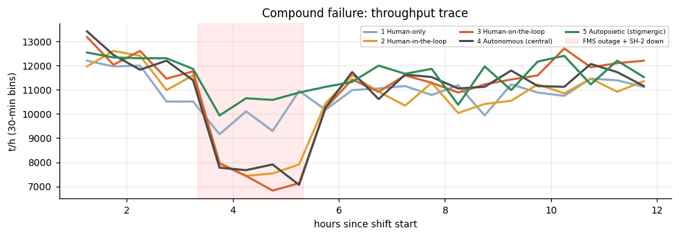

```python
rows = []
for m in names:
    d = R[("Normal shift", m)]
    rows.append({"Mode": m, "Human touches / shift": d.touches.mean(), "Touches per 1000 t": 1000 * d.touches.mean() / d.tons.mean(),
                 "Hold min/trip (4060/4150)": d.min_12.mean(), "Queue at source": d.queue_src.mean(), "Utilization %": d.utilization.mean(),
                 "A-stops": d.astops.mean()})
display(pd.DataFrame(rows).round(2))

fig, ax = plt.subplots(figsize=(9, 3.2))
for m, c in zip(names, cols):
    sims = KEEP[("Compound (both)", m)]; xs = tons_series(sims[0])[0]
    ax.plot(xs / 60, np.mean([tons_series(s)[1] for s in sims], 0), color=c, label=m, lw=2)
ax.axvspan(200 / 60, 320 / 60, color="red", alpha=0.08, label="FMS outage + SH-2 down")
ax.set_xlabel("hours since shift start"); ax.set_ylabel("t/h (30-min bins)"); ax.set_title("Compound failure: throughput trace"); ax.legend(fontsize=6, ncol=3)
plt.tight_layout(); plt.show()
```

### Input and output interpretation — operator workload and failure trace

- Human-only and HITL record about **331 and 338 operator touches per shift** (2.75–2.76 per 1,000 t). HOTL records about **4.5** exception touches. Autonomous-central and stigmergic record **zero operator touches** under the metric; their physical field/peer actions are not counted as control-room approvals.
- HITL spends **1.77 hold min/trip** in approval versus 0.50 for human-only and zero for the other three configurations. Its source queue is lower than human-only (2.45 vs 4.10 min), but hold time replaces part of that queue and utilization remains lower than HOTL (70.69 % vs 73.09 %).
- During the compound outage, HITL, HOTL and autonomous-central fall to roughly **6,800–8,000 t/h** in the middle of the failure window. Human-only remains around 9,100–10,100 t/h and stigmergic around 9,900–10,700 t/h. All traces return to the normal range within roughly an hour after the outage ends; the chart does not show a persistent release convoy.

**Output conclusion.** Per-decision approval creates measurable holding time and workload in this configured HITL mode. The compound-trace advantage belongs to both configurations that do not depend on the central FMS, with the stigmergic policy producing the higher overall compound-shift mean.

## 5. Sensitivity to the assumptions

Two assumptions decide the fight between humans and autonomy: **how slow a human approval is** and **how long an A-stop takes without a human**. (30 replications per point, normal shift; error bars are 95 % CIs.)

```
Reference (30 shifts): Human-on-the-loop 11,642 ± 134 | Human-only 10,973 ± 154
```

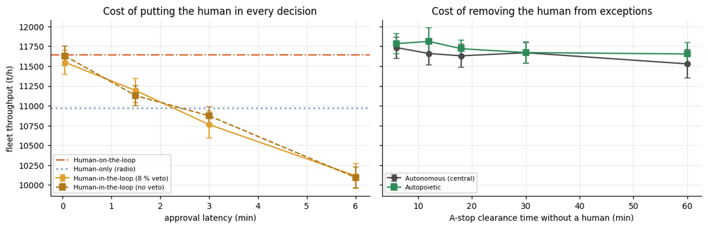

|  | HITL approval latency (min) | HITL, 8 % veto | HITL, no veto |
| --- | --- | --- | --- |
| 0 | 0.05 | 11,547 ± 152 | 11,629 ± 122 |
| 1 | 1.50 | 11,191 ± 149 | 11,127 ± 129 |
| 2 | 3.00 | 10,763 ± 171 | 10,873 ± 114 |
| 3 | 6.00 | 10,115 ± 153 | 10,095 ± 133 |

|  | A-stop clearance (min) | Autonomous (central) | Autopoietic |
| --- | --- | --- | --- |
| 0 | 6 | 11,733 ± 135 | 11,783 ± 128 |
| 1 | 12 | 11,659 ± 143 | 11,812 ± 169 |
| 2 | 18 | 11,629 ± 148 | 11,719 ± 108 |
| 3 | 30 | 11,668 ± 132 | 11,670 ± 134 |
| 4 | 60 | 11,528 ± 180 | 11,653 ± 145 |

```python
N = 30
lat = [0.05, 1.5, 3.0, 6.0]
h_veto = [replicate(lambda: HITL(approve_lat=x), n=N) for x in lat]
h_nov = [replicate(lambda: HITL(approve_lat=x, veto=0.0), n=N) for x in lat]
ref_hotl = replicate(HOTL, n=N); ref_hum = replicate(HumanOnly, n=N)
crew = [6, 12, 18, 30, 60]
a4 = [replicate(lambda: AutoCentral(astop_min=x), n=N) for x in crew]
a5 = [replicate(lambda: Autopoietic(astop_min=x), n=N) for x in crew]
ms = lambda dfs: (np.array([d.tph_fleet.mean() for d in dfs]), np.array([ci95(d.tph_fleet) for d in dfs]))
fmt = lambda dfs: [f"{d.tph_fleet.mean():,.0f} ± {ci95(d.tph_fleet):.0f}" for d in dfs]

fig, axs = plt.subplots(1, 2, figsize=(11, 3.6), sharey=True)
m, e = ms(h_veto); axs[0].errorbar(lat, m, e, marker="o", color="#e0a030", capsize=3, label="Human-in-the-loop (8 % veto)")
m, e = ms(h_nov); axs[0].errorbar(lat, m, e, marker="s", ls="--", color="#b07818", capsize=3, label="Human-in-the-loop (no veto)")
axs[0].axhline(ref_hotl.tph_fleet.mean(), color="#d9622b", ls="-.", label="Human-on-the-loop")
axs[0].axhline(ref_hum.tph_fleet.mean(), color="#8fa9c4", ls=":", lw=2, label="Human-only (radio)")
axs[0].set_xlabel("approval latency (min)"); axs[0].set_ylabel("fleet throughput (t/h)"); axs[0].legend(fontsize=7)
axs[0].set_title("Cost of putting the human in every decision")
m, e = ms(a4); axs[1].errorbar(crew, m, e, marker="o", color="#4a4a4a", capsize=3, label="Autonomous (central)")
m, e = ms(a5); axs[1].errorbar(crew, m, e, marker="s", color="#2e8b57", capsize=3, label="Autopoietic")
axs[1].set_xlabel("A-stop clearance time without a human (min)"); axs[1].legend(fontsize=7)
axs[1].set_title("Cost of removing the human from exceptions")
plt.tight_layout(); plt.show()

display(pd.DataFrame({"HITL approval latency (min)": lat, "HITL, 8 % veto": fmt(h_veto), "HITL, no veto": fmt(h_nov)}))
print(f"Reference (30 shifts): Human-on-the-loop {ref_hotl.tph_fleet.mean():,.0f} ± {ci95(ref_hotl.tph_fleet):.0f} | Human-only {ref_hum.tph_fleet.mean():,.0f} ± {ci95(ref_hum.tph_fleet):.0f}")
display(pd.DataFrame({"A-stop clearance (min)": crew, "Autonomous (central)": fmt(a4), "Autopoietic": fmt(a5)}))
```

### Input and output interpretation — approval and A-stop sensitivity

- With 8 % veto, HITL mean throughput falls from **11,547 ± 152 t/h** at 0.05-min approval to **11,191 ± 149** at 1.5 min, **10,763 ± 171** at 3 min and **10,115 ± 153** at 6 min. Reference means are **11,642 ± 134** for HOTL and **10,973 ± 154** for human-only.
- Near-zero approval is descriptively close to HOTL. By 3 min the HITL mean is below human-only, and by 6 min it is about 858 t/h below it. The comparison isolates approval latency within this HITL implementation, not the general value of human judgment.
- Removing the veto does not produce a consistent directional gain: no-veto minus veto ranges from **−64 to +110 t/h** across the four latency points. The data do not support assigning a fixed “veto cost.”
- Increasing non-operator A-stop clearance from 6 to 60 min changes central autonomy from **11,733 to 11,528 t/h** (−1.7 %) and stigmergic from **11,783 to 11,653 t/h** (−1.1 %). Intermediate means are not monotonic.
- These A-stop effects are small because the model generates only about four to five such events per shift. Rare severe incidents, safety accountability and loss of situation awareness are outside the productivity metric.

**Output conclusion.** Approval latency is the dominant tested input for the HITL configuration. The A-stop response-time effect is modest under the modeled event frequency and cannot be generalized to safety-critical tail events.

### 5.1 The compound-failure result depends on the fallback design

In the compound scenario (FMS outage + shovel SH-2 failure) the centralised modes hold their trucks and, after a while, fall back to the **static plan**; trucks already queued at the dead shovel cannot be redirected until the FMS returns. This fallback is a **modelling choice**, so we vary how long the centralised modes wait before falling back (30 shifts per cell).

```python
COMP = dict(system_outages=((200, 320),), shovel_outages=((1, 200, 320),))
fallbacks = [2.0, 10.0, 30.0, 1000.0]
auto_pd = replicate(Autopoietic, n=N, **COMP)                 # does not depend on the FMS, hence not on the fallback
rows = []
for f in fallbacks:
    r = {"Fall back to static plan after (min)": "never (hold until the FMS returns)" if f >= 1000 else f}
    for cls in (HOTL, AutoCentral):
        d = replicate(cls, n=N, fallback_min=f, **COMP); r[cls.name] = f"{d.tph_fleet.mean():,.0f} ± {ci95(d.tph_fleet):.0f}"
    r[Autopoietic.name] = f"{auto_pd.tph_fleet.mean():,.0f} ± {ci95(auto_pd.tph_fleet):.0f}"
    rows.append(r)
display(pd.DataFrame(rows))
```

|  | Fall back to static plan after (min) | 3 Human-on-the-loop | 4 Autonomous (central) | 5 Autopoietic (stigmergic) |
| --- | --- | --- | --- | --- |
| 0 | 2.0 | 10,972 ± 192 | 10,935 ± 176 | 11,602 ± 118 |
| 1 | 10.0 | 10,901 ± 161 | 10,872 ± 151 | 11,602 ± 118 |
| 2 | 30.0 | 10,715 ± 181 | 10,665 ± 152 | 11,602 ± 118 |
| 3 | never (hold until the FMS returns) | 8,995 ± 122 | 9,155 ± 110 | 11,602 ± 118 |

### Input and output interpretation — fallback sensitivity

- With a static fallback after 2, 10 and 30 min, HOTL produces **10,972 / 10,901 / 10,715 t/h** and autonomous-central **10,935 / 10,872 / 10,665 t/h**. The stigmergic reference is **11,602 ± 118 t/h** in this 30-shift sensitivity run.
- Earlier fallback improves the mean relative to waiting 30 min, although the 2-versus-10-min differences are small compared with replication uncertainty. The static fallback is still weak because it can assign trucks to the failed shovel and cannot centrally redirect them during the outage.
- If central configurations never fall back and hold until FMS recovery, HOTL and central autonomy fall to **8,995 and 9,155 t/h**. This is a deliberately poor failure response, not a property of centralised control itself.
- The stigmergic gap over the central configurations grows from roughly **630–667 t/h** with a 2-min fallback to **887–937 t/h** with a 30-min fallback. A local-sensing or radio-assisted central fallback was not tested and could narrow or remove that gap.

### Bottom line

1. In this model, putting approval inside every dispatch is competitive only when approval is nearly instantaneous; this conclusion is conditional on the specified algorithms and human inputs.
2. HOTL and autonomous-central are indistinguishable in normal operation. Their compound-failure performance depends more on fallback design than on the presence or absence of a supervisor.
3. A decentralised, self-organising layer is supported here as a **resilience fallback against a naive central fallback**, not as a universal productivity advantage.

## Limitations

- The five modes are bundles of information, timing, veto, dispatch, exception and fallback choices. Pairwise mode differences cannot identify a pure causal effect of “the human,” centralisation or autopoiesis.
- “Autopoietic” is used narrowly for an evaporating stigmergic dispatch layer. The implementation uses shared environmental marks and local outcomes but does not model self-production of components, new role formation, adversaries or organisational learning.
- The human model has fixed approval distributions, veto probability and breaks; it omits fatigue, expertise, shift handover and situation-awareness dynamics.
- Operator touches exclude field-crew or peer physical work in autonomous-central and stigmergic modes. The workload table must not be read as zero human labour.
- The compound test is one correlated-failure scenario. Network partition, GNSS loss, cyber events, weather and multiple equipment failures are not represented.
- Student-*t* intervals use independent simulated shifts and direct seed-indexed differences. Separate environment and policy RNGs reduce cross-contamination, but policy-dependent state histories still diverge.
- The reduced-form mine has no grade/blend, route network, production-plan or safety constraints. The five-shovel calibration structure also overstates baseline hang time.
- The model measures throughput resilience only. It cannot support conclusions about collision risk, legal accountability or the required human role in a safety case.

## References

1. **[TUM]** Operator's *Operations & Supply Chain Management – Time Usage Model (TUM): Our Requirements*, v7.0 (12 Jan 2023), internal standard (Company X). Time definitions, classification categories, parameters (availability, utilization, annualised production time), reliability parameters (MTBF, MTTR) and the standard time codes.
2. **[DASH]** Autonomous-haulage operations dashboard pack ("Autonomous-Haulage Dashboard"), Mine A, extracts for 9–16 March 2025: Tonnage Origin/Destination, Crusher Feed, Availability, Utilization, Throughput, Autonomous Fleet (cycle phases), Shovel, Duration, Annualised, and the dashboard-by-dashboard KPI list.
3. **[GLOS]** *Full TUM Glossary* – general time terms, downtime classification, standard parameters, reliability parameters and code families.
4. **[KPI]** *KPI Control Template – Mine A (improved version)* – expected ranges: availability > 85 %, utilization > 60 %, MTBF > 10 h, MTTR < 2 h, hang time < 2 min, load factor 2.5–3 passes, non-productive time (7000–7020) < 10 %.
5. **[CYCLE]** Mining haul-cycle diagram: ten cycle phases – travelling empty, queuing/spotting at source, wait for load, loading, travelling full, queuing/spotting at sink, wait for dump, dumping.
6. **[BANKS]** Banks, J., Carson, J. S., Nelson, B. L. & Nicol, D. M. (2010). *Discrete-Event System Simulation* (5th ed.). Pearson. (Warm-up, replications, confidence intervals, verification and validation.)
7. **[LAW]** Law, A. M. (2015). *Simulation Modeling and Analysis* (5th ed.). McGraw-Hill.
8. **[LITTLE]** Little, J. D. C. (1961). A proof for the queuing formula L = λW. *Operations Research*, 9(3), 383–387.
9. **[AG]** Alarie, S. & Gamache, M. (2002). Overview of solution strategies used in truck dispatching systems for open pit mines. *International Journal of Surface Mining, Reclamation and Environment*, 16(1), 59–76.
10. **[PSW]** Parasuraman, R., Sheridan, T. B. & Wickens, C. D. (2000). A model for types and levels of human interaction with automation. *IEEE Transactions on Systems, Man, and Cybernetics – Part A*, 30(3), 286–297.
11. **[BAIN]** Bainbridge, L. (1983). Ironies of automation. *Automatica*, 19(6), 775–779.
12. **[ENDS]** Endsley, M. R. & Kiris, E. O. (1995). The out-of-the-loop performance problem and level of control in automation. *Human Factors*, 37(2), 381–394.
13. **[MV]** Maturana, H. R. & Varela, F. J. (1980). *Autopoiesis and Cognition: The Realization of the Living*. D. Reidel.
14. **[GRASSE]** Grassé, P.-P. (1959). The reconstruction of the nest and interindividual coordination in *Bellicositermes natalensis* and *Cubitermes* sp. (original title in French). *Insectes Sociaux*, 6, 41–80.
15. **[BDT]** Bonabeau, E., Dorigo, M. & Theraulaz, G. (1999). *Swarm Intelligence: From Natural to Artificial Systems*. Oxford University Press.
16. **[DORIGO]** Dorigo, M. & Stützle, T. (2004). *Ant Colony Optimization*. MIT Press.
17. **[TAL]** Taleb, N. N. (2012). *Antifragile: Things That Gain from Disorder*. Random House.

## Disclaimer

This notebook is an exploratory simulation based on anonymised aggregate indicators and a simplified representation of an open-pit haulage system. It is not an operator model, a production forecast, a safety case or an operating recommendation. Parameters that were not observable—including event rates, communication effects and human-response times—are explicit assumptions, and the outputs are conditional on those assumptions and on the model structure.

Company, mine, location and equipment identifiers have been anonymised. The work is independent and is not endorsed by, or affiliated with, any mining company or technology vendor. Operational, investment and safety decisions require validation against held-out FMS event data, mine-plan constraints and the applicable engineering and safety standards.